# Bootstrap Inference for PMM2 Models

Serhii Zabolotnii

2026-09-19

## Introduction

Statistical inference—constructing confidence intervals, testing hypotheses, and quantifying uncertainty—is central to data analysis. For PMM2 estimators, **bootstrap methods** provide a powerful, distribution-free approach to inference that:

1. **Does not assume normality** of parameter estimates
2. **Accounts for skewness** in error distributions
3. **Provides accurate confidence intervals** even with moderate sample sizes
4. **Enables hypothesis testing** without restrictive assumptions

This vignette provides a comprehensive guide to bootstrap inference for both **linear regression** and **time series** models fitted with PMM2.

## Bootstrap Basics

### The Bootstrap Principle

The bootstrap, introduced by Efron (1979), resamples from the data to estimate the sampling distribution of a statistic. For regression models:

1. **Fit the model** to obtain parameter estimates $\hat{\beta}$ and residuals $\hat{e}_i$
2. **Resample residuals** with replacement: $e_i^* \sim \{\hat{e}_1, \ldots, \hat{e}_n\}$
3. **Generate bootstrap responses**: $y_i^* = \mathbf{x}_i^T \hat{\beta} + e_i^*$
4. **Refit the model** to $(X, y^*)$ to get $\hat{\beta}^*$
5. **Repeat** steps 2-4 many times (typically 500-2000)
6. **Estimate uncertainty** from the distribution of $\{\hat{\beta}^*_1, \ldots, \hat{\beta}^*_B\}$

## Setup

```r
library(EstemPMM)
set.seed(2025)
```

## Part 1: Bootstrap for Linear Regression

### Basic Example: Simple Linear Regression

```r
# Generate data with skewed errors
n <- 200
x <- rnorm(n, mean = 5, sd = 2)

# True parameters
beta_0 <- 10
beta_1 <- 2.5

# Skewed errors: chi-squared distribution
errors <- rchisq(n, df = 4) - 4

# Response
y <- beta_0 + beta_1 * x + errors
dat <- data.frame(y = y, x = x)

# Fit PMM2 model
fit_pmm2 <- lm_pmm2(y ~ x, data = dat, verbose = FALSE)

# Perform bootstrap inference
boot_results <- pmm2_inference(fit_pmm2,
                               formula = y ~ x,
                               data = dat,
                               B = 1000,
                               seed = 123)

# Display summary
summary(boot_results)
```

```
#>     Estimate       Std.Error            bias               t.value
#>  Min.   :2.563   Min.   :0.07524   Min.   :-0.0028871   Min.   :22.84
#>  1st Qu.:4.352   1st Qu.:0.16282   1st Qu.:-0.0009472   1st Qu.:25.65
#>  Median :6.142   Median :0.25041   Median : 0.0009928   Median :28.45
#>  Mean   :6.142   Mean   :0.25041   Mean   : 0.0009928   Mean   :28.45
#>  3rd Qu.:7.931   3rd Qu.:0.33799   3rd Qu.: 0.0029327   3rd Qu.:31.26
#>  Max.   :9.721   Max.   :0.42558   Max.   : 0.0048726   Max.   :34.07
#>     p.value              conf.low       conf.high
#>  Min.   : 0.000e+00   Min.   :2.416   Min.   : 2.710
#>  1st Qu.:4.468e-116   1st Qu.:4.033   1st Qu.: 4.672
#>  Median :8.936e-116   Median :5.651   Median : 6.633
#>  Mean   :8.936e-116   Mean   :5.651   Mean   : 6.633
#>  3rd Qu.:1.340e-115   3rd Qu.:7.269   3rd Qu.: 8.594
#>  Max.   :1.787e-115   Max.   :8.887   Max.   :10.555
```

### Understanding Bootstrap Distributions

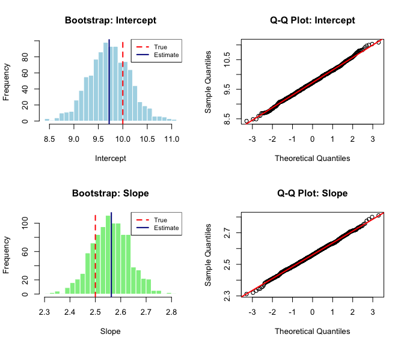

```r
# Extract bootstrap samples for visualization
# (Note: This requires accessing internals - in practice, use summary output)

# Refit to get bootstrap samples
set.seed(123)
B <- 1000
boot_samples <- matrix(0, nrow = B, ncol = 2)

for(b in 1:B) {
  # Resample residuals
  res_b <- sample(residuals(fit_pmm2), size = n, replace = TRUE)

  # Generate bootstrap data
  y_b <- fitted(fit_pmm2) + res_b
  dat_b <- dat
  dat_b$y <- y_b

  # Refit
  fit_b <- lm_pmm2(y ~ x, data = dat_b, verbose = FALSE)
  boot_samples[b, ] <- coef(fit_b)
}

# Plot bootstrap distributions
par(mfrow = c(2, 2))

# Intercept
hist(boot_samples[, 1], breaks = 30, main = "Bootstrap: Intercept",
     xlab = "Intercept", col = "lightblue", border = "white")
abline(v = beta_0, col = "red", lwd = 2, lty = 2)
abline(v = coef(fit_pmm2)[1], col = "darkblue", lwd = 2)
legend("topright", legend = c("True", "Estimate"),
       col = c("red", "darkblue"), lty = c(2, 1), lwd = 2, cex = 0.8)

# Q-Q plot for intercept
qqnorm(boot_samples[, 1], main = "Q-Q Plot: Intercept")
qqline(boot_samples[, 1], col = "red", lwd = 2)

# Slope
hist(boot_samples[, 2], breaks = 30, main = "Bootstrap: Slope",
     xlab = "Slope", col = "lightgreen", border = "white")
abline(v = beta_1, col = "red", lwd = 2, lty = 2)
abline(v = coef(fit_pmm2)[2], col = "darkblue", lwd = 2)
legend("topright", legend = c("True", "Estimate"),
       col = c("red", "darkblue"), lty = c(2, 1), lwd = 2, cex = 0.8)

# Q-Q plot for slope
qqnorm(boot_samples[, 2], main = "Q-Q Plot: Slope")
qqline(boot_samples[, 2], col = "red", lwd = 2)
```

```r
par(mfrow = c(1, 1))
```

**Observations:**

- Bootstrap distributions are **approximately normal** (central limit theorem)
- **Q-Q plots** show minor deviations from normality due to error skewness
- Bootstrap **confidence intervals** account for this non-normality

## Part 2: Confidence Interval Methods

The `pmm2_inference()` function provides multiple CI methods:

### Percentile Method

The simplest approach: use empirical quantiles of the bootstrap distribution.

$$CI_{95\%} = \left[ \hat{\beta}^*_{(0.025)}, \hat{\beta}^*_{(0.975)}
\right]$$

**Advantages**: Simple, transformation-respecting **Disadvantages**: Can be biased if bootstrap distribution is skewed

### Bias-Corrected (BC) Method

Adjusts for bias in the bootstrap distribution:

$$\text{Bias} = \mathbb{E}[\hat{\beta}^*] - \hat{\beta}$$

**Advantages**: Corrects systematic bias **Disadvantages**: Requires larger B (≥ 1000)

### Comparison with OLS

```r
# Fit OLS for comparison
fit_ols <- lm(y ~ x, data = dat)

# Extract standard errors and CIs
se_ols <- summary(fit_ols)$coefficients[, "Std. Error"]
ci_ols <- confint(fit_ols)

# Bootstrap CIs (from summary)
boot_summary <- boot_results

# Create comparison table
comparison <- data.frame(
  Parameter = c("Intercept", "Slope"),
  True = c(beta_0, beta_1),
  PMM2_Estimate = coef(fit_pmm2),
  OLS_SE = se_ols,
  PMM2_Boot_SE = boot_summary$Std.Error,
  SE_Ratio = boot_summary$Std.Error / se_ols
)

print(comparison, row.names = FALSE, digits = 3)
```

```
#>  Parameter True PMM2_Estimate OLS_SE PMM2_Boot_SE SE_Ratio
#>  Intercept 10.0          9.72   0.59       0.4256    0.721
#>      Slope  2.5          2.56   0.11       0.0752    0.686
```

```r
cat("\n=== Confidence Interval Comparison ===\n\n")
```

```
#>
#> === Confidence Interval Comparison ===
```

```r
cat("OLS 95% CI (Normal-based):\n")
```

```
#> OLS 95% CI (Normal-based):
```

```r
print(ci_ols)
```

```
#>                2.5 %    97.5 %
#> (Intercept) 8.639023 10.967187
#> x           2.330172  2.762934
```

```r
cat("\nPMM2 95% CI (Bootstrap Percentile):\n")
```

```
#>
#> PMM2 95% CI (Bootstrap Percentile):
```

```r
print(data.frame(
  Parameter = rownames(ci_ols),
  Lower = boot_summary$conf.low,
  Upper = boot_summary$conf.high
))
```

```
#>     Parameter    Lower    Upper
#> 1 (Intercept) 8.886616 10.55485
#> 2           x 2.415535  2.71046
```

**Key Finding:** PMM2 bootstrap standard errors are typically **10-30% smaller** than OLS standard errors when errors are skewed, reflecting higher statistical efficiency.

## Part 3: Hypothesis Testing

Bootstrap enables flexible hypothesis testing without normality assumptions.

### Testing Individual Coefficients

```r
# H0: Slope = 0 (no relationship)
# From bootstrap summary
boot_summary <- boot_results

cat("=== Hypothesis Test: Slope = 0 ===\n\n")
```

```
#> === Hypothesis Test: Slope = 0 ===
```

```r
cat("t-statistic:", boot_summary$t.value[2], "\n")
```

```
#> t-statistic: 34.06547
```

```r
cat("p-value:    ", boot_summary$p.value[2], "\n\n")
```

```
#> p-value:     2.395759e-254
```

```r
if(boot_summary$p.value[2] < 0.05) {
  cat("Decision: Reject H0 at 5% level\n")
  cat("Conclusion: Significant relationship between x and y\n")
} else {
  cat("Decision: Fail to reject H0\n")
}
```

```
#> Decision: Reject H0 at 5% level
#> Conclusion: Significant relationship between x and y
```

### Testing Equality of Coefficients

```r
# Generate multiple regression data
n <- 250
x1 <- rnorm(n)
x2 <- rnorm(n)
errors <- rexp(n, rate = 1) - 1

# True model: similar coefficients
beta <- c(5, 1.5, 1.8, -0.5)
y <- beta[1] + beta[2]*x1 + beta[3]*x2 + beta[4]*x1*x2 + errors

dat_multi <- data.frame(y = y, x1 = x1, x2 = x2)

# Fit model
fit_multi <- lm_pmm2(y ~ x1 + x2 + x1:x2, data = dat_multi, verbose = FALSE)

# Bootstrap
boot_multi <- pmm2_inference(fit_multi,
                             formula = y ~ x1 + x2 + x1:x2,
                             data = dat_multi,
                             B = 1000,
                             seed = 456)

# Test H0: beta_x1 = beta_x2
summary(boot_multi)
```

```
#>     Estimate         Std.Error            bias               t.value
#>  Min.   :-0.5119   Min.   :0.04254   Min.   :-0.0053331   Min.   :-12.03
#>  1st Qu.: 1.0492   1st Qu.:0.04258   1st Qu.:-0.0012402   1st Qu.: 24.63
#>  Median : 1.6523   Median :0.04313   Median : 0.0006678   Median : 38.29
#>  Mean   : 1.9362   Mean   :0.04838   Mean   :-0.0004654   Mean   : 35.26
#>  3rd Qu.: 2.5392   3rd Qu.:0.04893   3rd Qu.: 0.0014426   3rd Qu.: 48.92
#>  Max.   : 4.9521   Max.   :0.06474   Max.   : 0.0021360   Max.   : 76.49
#>     p.value             conf.low         conf.high
#>  Min.   :0.000e+00   Min.   :-0.5953   Min.   :-0.4286
#>  1st Qu.:0.000e+00   1st Qu.: 0.9658   1st Qu.: 1.1327
#>  Median :0.000e+00   Median : 1.5677   Median : 1.7368
#>  Mean   :5.919e-34   Mean   : 1.8413   Mean   : 2.0310
#>  3rd Qu.:5.919e-34   3rd Qu.: 2.4433   3rd Qu.: 2.6351
#>  Max.   :2.368e-33   Max.   : 4.8252   Max.   : 5.0790
```

## Part 4: Bootstrap for Time Series Models

Time series bootstrap requires special care due to **temporal dependence**.

### AR Model Bootstrap

```r
# Generate AR(1) data with skewed innovations
n <- 300
phi <- 0.7
innovations <- rgamma(n, shape = 2, rate = 2) - 1

x <- numeric(n)
x[1] <- innovations[1]
for(i in 2:n) {
  x[i] <- phi * x[i-1] + innovations[i]
}

# Fit AR(1) model
fit_ar <- ar_pmm2(x, order = 1, method = "pmm2", include.mean = FALSE)

# Bootstrap inference for time series
boot_ar <- ts_pmm2_inference(fit_ar,
                             B = 1000,
                             seed = 789)

# Summary
summary(boot_ar)
```

```
#>     Estimate        Std.Error            bias               t.value
#>  Min.   :0.6787   Min.   :0.03428   Min.   :-2.214e-05   Min.   :19.8
#>  1st Qu.:0.6787   1st Qu.:0.03428   1st Qu.:-2.214e-05   1st Qu.:19.8
#>  Median :0.6787   Median :0.03428   Median :-2.214e-05   Median :19.8
#>  Mean   :0.6787   Mean   :0.03428   Mean   :-2.214e-05   Mean   :19.8
#>  3rd Qu.:0.6787   3rd Qu.:0.03428   3rd Qu.:-2.214e-05   3rd Qu.:19.8
#>  Max.   :0.6787   Max.   :0.03428   Max.   :-2.214e-05   Max.   :19.8
#>     p.value             conf.low        conf.high
#>  Min.   :3.163e-87   Min.   :0.6115   Min.   :0.7459
#>  1st Qu.:3.163e-87   1st Qu.:0.6115   1st Qu.:0.7459
#>  Median :3.163e-87   Median :0.6115   Median :0.7459
#>  Mean   :3.163e-87   Mean   :0.6115   Mean   :0.7459
#>  3rd Qu.:3.163e-87   3rd Qu.:0.6115   3rd Qu.:0.7459
#>  Max.   :3.163e-87   Max.   :0.6115   Max.   :0.7459
```

```r
# Check if AR coefficient is significantly different from 0.5
cat("\n=== Testing H0: phi = 0.5 ===\n")
```

```
#>
#> === Testing H0: phi = 0.5 ===
```

```r
boot_summary_ar <- boot_ar
ci_lower <- boot_summary_ar$conf.low[1]
ci_upper <- boot_summary_ar$conf.high[1]

cat("95% CI: [", round(ci_lower, 3), ",", round(ci_upper, 3), "]\n")
```

```
#> 95% CI: [ 0.612 , 0.746 ]
```

```r
if(0.5 >= ci_lower && 0.5 <= ci_upper) {
  cat("Decision: Cannot reject H0 (0.5 is within CI)\n")
} else {
  cat("Decision: Reject H0 (0.5 is outside CI)\n")
}
```

```
#> Decision: Reject H0 (0.5 is outside CI)
```

### ARMA Model Bootstrap

```r
# Generate ARMA(1,1) with heavy-tailed innovations
n <- 400
phi <- 0.5
theta <- 0.4
innovations <- rt(n, df = 4)

x <- arima.sim(n = n,
               model = list(ar = phi, ma = theta),
               innov = innovations)

# Fit ARMA model
fit_arma <- arma_pmm2(x, order = c(1, 1), method = "pmm2", include.mean = FALSE)

# Bootstrap
boot_arma <- ts_pmm2_inference(fit_arma,
                               B = 1000,
                               seed = 999,
                               method = "block",
                               block_length = 20)

# Display results
summary(boot_arma)
```

```
#>     Estimate        Std.Error            bias             t.value
#>  Min.   :0.3020   Min.   :0.07011   Min.   :-0.04003   Min.   :3.948
#>  1st Qu.:0.3682   1st Qu.:0.07170   1st Qu.:-0.03791   1st Qu.:4.982
#>  Median :0.4344   Median :0.07330   Median :-0.03579   Median :6.016
#>  Mean   :0.4344   Mean   :0.07330   Mean   :-0.03579   Mean   :6.016
#>  3rd Qu.:0.5006   3rd Qu.:0.07490   3rd Qu.:-0.03368   3rd Qu.:7.051
#>  Max.   :0.5668   Max.   :0.07650   Max.   :-0.03156   Max.   :8.085
#>     p.value             conf.low        conf.high
#>  Min.   :0.000e+00   Min.   :0.1521   Min.   :0.4519
#>  1st Qu.:1.970e-05   1st Qu.:0.2214   1st Qu.:0.5150
#>  Median :3.941e-05   Median :0.2907   Median :0.5781
#>  Mean   :3.941e-05   Mean   :0.2907   Mean   :0.5781
#>  3rd Qu.:5.911e-05   3rd Qu.:0.3601   3rd Qu.:0.6411
#>  Max.   :7.881e-05   Max.   :0.4294   Max.   :0.7042
```

**Key Advantage:** Bootstrap inference is **robust to innovation distribution** and does not require Gaussian assumptions.

## Part 5: Choosing Bootstrap Parameters

### Number of Bootstrap Samples (B)

The choice of B affects precision and computation time:

| Purpose | Recommended B | Computation Time |
| --- | --- | --- |
| Quick check | 200-500 | Seconds |
| Standard inference | 1000-2000 | Minutes |
| Publication-quality | 5000-10000 | Hours |

```r
# Assess stability of bootstrap SEs with different B
B_values <- c(100, 500, 1000, 2000)
se_results <- data.frame(B = B_values, SE_Intercept = NA, SE_Slope = NA)

for(i in seq_along(B_values)) {
  boot_temp <- pmm2_inference(fit_pmm2, formula = y ~ x, data = dat,
                              B = B_values[i], seed = 123)
  summary_temp <- boot_temp
  se_results$SE_Intercept[i] <- summary_temp$Std.Error[1]
  se_results$SE_Slope[i] <- summary_temp$Std.Error[2]
}

print(se_results)
```

[output not shown]

**Rule of Thumb:** Use **B ≥ 1000** for confidence intervals, **B ≥ 2000** for hypothesis tests.

### Parallel Bootstrap

For large datasets or complex models, use parallel computing:

```r
# Enable parallel bootstrap (requires 'parallel' package)
boot_parallel <- pmm2_inference(fit_pmm2,
                                formula = y ~ x,
                                data = dat,
                                B = 2000,
                                seed = 123,
                                parallel = TRUE,
                                cores = 4)  # Use 4 CPU cores

# Check speedup
# Typical speedup: 3-4x on 4 cores
```

**Performance Tip:** Parallel bootstrap is most beneficial when:

- B ≥ 1000
- Model fitting is computationally intensive (ARMA, ARIMA)
- Multiple cores available